# Project 3 - Draft

The regression problem this project aims to solve is predicting sales volume and reorder quantities using the "Grocery Inventory and Sales Dataset" sourced from Kaggle. The dataset contains information on grocery products, including product categories, supplier details, stock levels, pricing, and sales performance metrics. By analyzing this dataset, we can gain insights into inventory and sales dynamics within the grocery sector.

Predicting sales volume and reorder quantities is a powerful tool for optimizing inventory management and supply chain efficiency. Challenges such as stockouts, overstocking, and food waste, can impact operational costs and customer satisfaction. By building a predictive model, this project aims to assist grocery stores in forecasting product demand more accurately leading to better inventory control and reducing waste. However, there are still some potential risks, such as over-reliance on the model, which might fail to account for unexpected demand surges during seasonal events or holidays.

The "Grocery Inventory and Sales Dataset" includes data on 990 products across various categories like Grains & Pulses, Beverages, and Fruits & Vegetables. Key features of the dataset include:

- Reorder_Level: The stock level at which new stock should be ordered.
- Reorder_Quantity: The quantity of product to order when the stock reaches the reorder level.
- Sales_Volume: The total number of units sold.
- Inventory_Turnover_Rate: The rate at which the product sells and is replenished.

## What is Regression?

Before we get started, let discuss first what is regression and how does it apply to our problem statement? Regression is a statistical method used to predict a dependent variable based on one or more independent variables. In the context of this project, regression allows us to analyze the relationship between features like stock quantity, reorder level, and unit price (independent variables) and the sales volume or reorder quantity (dependent variables). Specifically, linear regression is one of the simplest forms of regression, where the relationship between the variables is modeled as a straight line.

Linear regression works by minimizing the error between the actual values and the predicted values through a process called Ordinary Least Squares (OLS). It calculates the optimal values for the coefficients, outputing the line of best fit. In this project, using regression to predict sales volume or reorder quantities can help grocery stores identify trends and optimize inventory management, reducing waste and improving efficiency.

## Data Understanding

Before diving right into the work, what steps do you take to first gain an understanding of your data? For example, are any features correlated with each other? Are there any existing patterns? What visualizations can you make to help gain this initial understanding?

```python
import pandas as pd
import seaborn as sns
import matplotlib.pyplot as plt
from sklearn.linear_model import LinearRegression
from sklearn.model_selection import train_test_split
from sklearn.preprocessing import StandardScaler, PolynomialFeatures, LabelEncoder
from sklearn.metrics import mean_squared_error, r2_score
import statsmodels.api as sm
from datetime import datetime
```

```python
df = pd.read_csv("Grocery_Inventory_and_Sales_Dataset.csv")
df.describe()
```

|  | Stock_Quantity | Reorder_Level | Reorder_Quantity | Sales_Volume | Inventory_Turnover_Rate |
| --- | --- | --- | --- | --- | --- |
| count | 990.000000 | 990.000000 | 990.000000 | 990.000000 | 990.000000 |
| mean | 55.609091 | 51.215152 | 51.913131 | 58.925253 | 50.150505 |
| std | 26.300775 | 29.095241 | 29.521059 | 23.002318 | 28.798954 |
| min | 10.000000 | 1.000000 | 1.000000 | 20.000000 | 1.000000 |
| 25% | 33.000000 | 25.250000 | 25.000000 | 39.000000 | 25.000000 |
| 50% | 56.000000 | 53.000000 | 54.000000 | 58.000000 | 50.000000 |
| 75% | 79.000000 | 77.000000 | 77.000000 | 78.000000 | 74.750000 |
| max | 100.000000 | 100.000000 | 100.000000 | 100.000000 | 100.000000 |

```python
df.dtypes
```

```
Product_ID                 object
Product_Name               object
Catagory                   object
Supplier_ID                object
Supplier_Name              object
Stock_Quantity              int64
Reorder_Level               int64
Reorder_Quantity            int64
Unit_Price                 object
Date_Received              object
Last_Order_Date            object
Expiration_Date            object
Warehouse_Location         object
Sales_Volume                int64
Inventory_Turnover_Rate     int64
Status                     object
dtype: object
```

Notes currently: I want to convert 'unit_price' to float

```python
df["Unit_Price"] = df["Unit_Price"].str.replace("$", "").str.replace(",", "").astype(float)
```

For now I think its okay to just have the numerical data in the correlation map since most of them are the high importance

```python
numerical_data = df.select_dtypes(include=["int64", "float64"])
```

From the correlation map, we can see that the 'Sales_Volume' and the 'Inventory_Turnover_Rate' have a correlation of 0.06 which although small indicates that as a products sales volume increases, the inventory turnovermight not increase equality. This highlights issues in stock quantities and restocking practices.

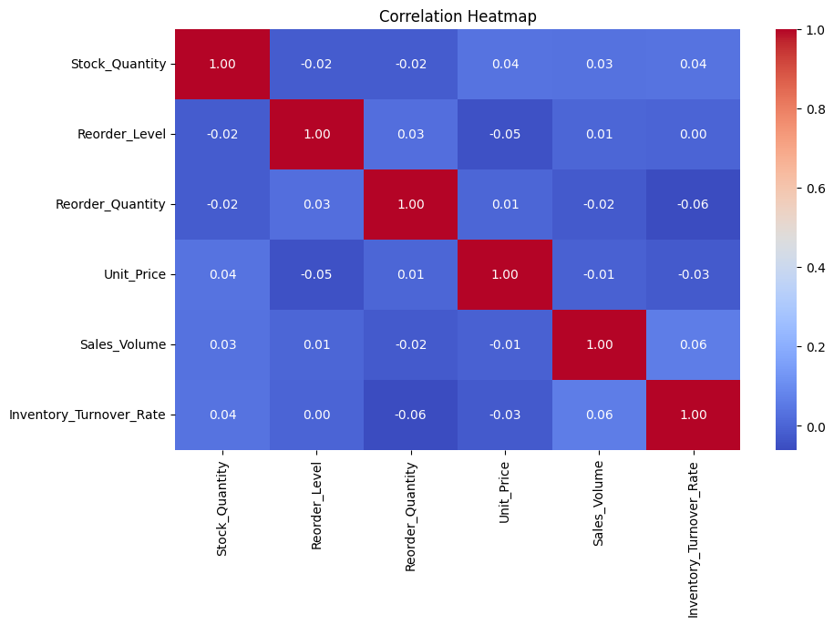

```python
correlation_matrix = numerical_data.corr()

plt.figure(figsize=(10, 6))
sns.heatmap(correlation_matrix, annot=True, cmap="coolwarm", fmt=".2f")
plt.title("Correlation Heatmap")
plt.show()
```

Current notes: from the histograph I can see the sale volume is balanced throughout so its not skewed towards low or high numbers. It is slightly higher in the lower numbers though.

for the unit prices, we can see an average btwn 0-20 with the highest outlier at 100. it is a tighter box so a majority of the products seem to be priced similarly.

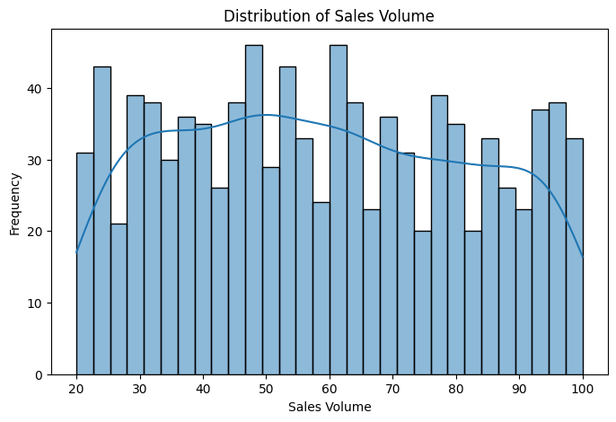

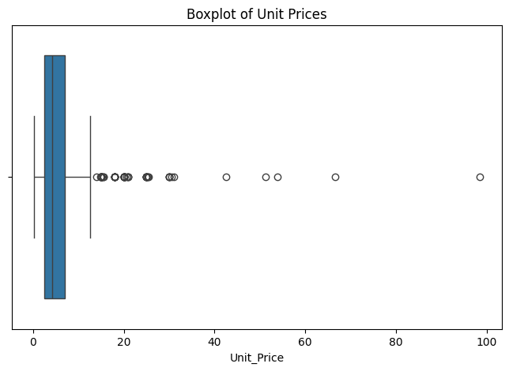

```python
#a histograph of the 'sales_volume' column
plt.figure(figsize=(8, 5))
sns.histplot(df["Sales_Volume"], kde=True, bins=30)
plt.title("Distribution of Sales Volume")
plt.xlabel("Sales Volume")
plt.ylabel("Frequency")
plt.show()

# Boxplot of unit prices
plt.figure(figsize=(8, 5))
sns.boxplot(x=df["Unit_Price"])
plt.title("Boxplot of Unit Prices")
plt.show()
```

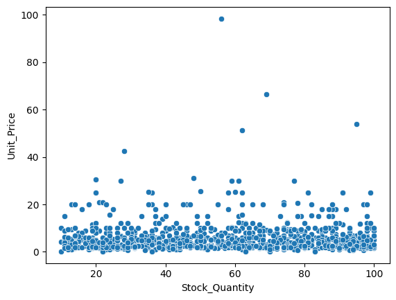

```python
sns.scatterplot(x='Stock_Quantity', y='Unit_Price', data=df)
```

## Data Pre-Processing and Cleaning

After the initial understanding, what steps need to be taken? Do you need to deal with null values? What features are you going to try using for your first experiment and why? Do you need to transform any features (e.g., change from categorical to numerical)? Are you trying to create any new features to use?

```python
df.isnull().sum()
```

```
Product_ID                 0
Product_Name               0
Catagory                   1
Supplier_ID                0
Supplier_Name              0
Stock_Quantity             0
Reorder_Level              0
Reorder_Quantity           0
Unit_Price                 0
Date_Received              0
Last_Order_Date            0
Expiration_Date            0
Warehouse_Location         0
Sales_Volume               0
Inventory_Turnover_Rate    0
Status                     0
dtype: int64
```

```python
df.duplicated().sum()
```

```
np.int64(0)
```

```python
df.dtypes
```

[output not shown]

```python
set(df['Status'].to_list())
```

```
{'Active', 'Backordered', 'Discontinued'}
```

```python
df['Status'] = df['Status'].replace(['Active', 'Backordered', 'Discontinued'], [0,1,2])
```

To change the date columns, I will use the datetime.now() to engineer new features and drop the current ones. I'm not sure how to convert the warehouse or supplier info. Since Im not 100% sure if they are really relavant I don't know if I should convert them to int or drop them.

```python
df["Date_Received"] = pd.to_datetime(df["Date_Received"])
df["Days_Since_Received"] = (datetime.now() - df["Date_Received"]).dt.days

df["Last_Order_Date"] = pd.to_datetime(df["Last_Order_Date"])
df["Days_Since_Last_Order"] = (datetime.now() - df["Last_Order_Date"]).dt.days

df["Expiration_Date"] = pd.to_datetime(df["Expiration_Date"])
df["Days_to_Expiration"] = (df["Expiration_Date"] - datetime.now()).dt.days

df = df.drop(columns=['Product_ID'])
df = df.drop(columns=['Date_Received', 'Last_Order_Date', "Expiration_Date"])
```

```python
df["Order_Recency"] = df["Days_Since_Received"] - df["Days_Since_Last_Order"]
```

```python
df = pd.get_dummies(df, columns = ["Catagory"], dtype=int)
df.head()
```

|  | Product_Name | Supplier_ID | Supplier_Name | Stock_Quantity | Reorder_Level | Reorder_Quantity | Unit_Price | Warehouse_Location | Sales_Volume | Inventory_Turnover_Rate | ... | Catagory_Beverages | Catagory_Dairy | Catagory_Fruits & Vegetables | Catagory_Grains & Pulses | Catagory_Oils & Fats | Catagory_Seafood | Days_Since_Received | Days_Since_Last_Order | Order_Recency | Days_to_Expiration |
| --- | --- | --- | --- | --- | --- | --- | --- | --- | --- | --- | --- | --- | --- | --- | --- | --- | --- | --- | --- | --- | --- |
| 0 | Sushi Rice | 38-037-1699 | Jaxnation | 22 | 72 | 70 | 4.5 | 48 Del Sol Trail | 32 | 19 | ... | 0 | 0 | 0 | 1 | 0 | 0 | 220 | 268 | -48 | -187 |
| 1 | Arabica Coffee | 54-470-2479 | Feedmix | 45 | 77 | 2 | 20.0 | 36 3rd Place | 85 | 1 | ... | 1 | 0 | 0 | 0 | 0 | 0 | 143 | 299 | -156 | -321 |
| 2 | Black Rice | 54-031-2945 | Vinder | 30 | 38 | 83 | 6.0 | 3296 Walton Court | 31 | 34 | ... | 0 | 0 | 0 | 1 | 0 | 0 | 233 | 287 | -54 | -184 |
| 3 | Long Grain Rice | 63-492-7603 | Brightbean | 12 | 59 | 62 | 1.5 | 3 Westerfield Crossing | 95 | 99 | ... | 0 | 0 | 0 | 1 | 0 | 0 | 106 | 33 | 73 | -342 |
| 4 | Plum | 54-226-4308 | Topicstorm | 37 | 30 | 74 | 4.0 | 15068 Scoville Court | 62 | 25 | ... | 0 | 0 | 1 | 0 | 0 | 0 | 264 | 164 | 100 | -171 |

5 rows × 22 columns

The features I want to include in my first experiment would be:

- Stock_Quantity: since the quantity is directly related to sales
- Reorder_Level: Helps identify if reorder trends influence sales or reorders.
- Category: Certain categories might sell better than others.
- Inventory_Turnover_Rate: Tracks product demand
- Unit_Price: Price can influence customer purchasing decisions.

I selected these features since they are directly related to sales and inventory dynamics, making them the best starting points.

I have some ideas for the next experiment where I create features like profit margin or sales rate! Using current features to hopefully bring up the accuracy

## Modeling Experiment #1

Create a linear regression model for your first experiment. This one will predict the sales volume

```python
X = df[["Stock_Quantity", "Reorder_Level", "Unit_Price", "Inventory_Turnover_Rate", "Catagory_Bakery", "Catagory_Beverages", "Catagory_Dairy","Catagory_Fruits & Vegetables","Catagory_Grains & Pulses","Catagory_Oils & Fats","Catagory_Seafood"]]
y = df["Sales_Volume"]
```

```python
reg = LinearRegression().fit(X, y)
```

```python
reg.coef_
```

```
array([ 2.13482525e-02,  3.74994870e-04, -1.21890529e-01,  4.40301880e-02,
        1.76322735e+01,  1.79332420e+01,  1.56831942e+01,  1.45776238e+01,
        1.10237385e+01,  1.60905180e+01,  1.85423077e+01])
```

```python
reg.score(X, y)
```

```
0.014182046934485215
```

```python
X_train, X_test, Y_train, Y_test = train_test_split(X,y, test_size = 0.2, random_state =42)
```